# ML student R

Enrique Rodríguez Morón

26 Noviembre 2017

# Introducción

El [dataset](https://archive.ics.uci.edu/ml/machine-learning-databases/00320/student.zip)[^1] que se va a utilizar contiene los datos de las calificaciones de alumnos de educación secundaria en 2 escuelas portuguesas. Dentro del zip que se descarga, hay dos ficheros con datos correspondiente a la asignatura de matemáticas (student-mat.csv) y portugués (student-por.csv).

A parte de las calificaciones obtenidas se tienen una serie de atributos por cada alumno, como puede ser edad, escuela o tiempo dedicado a salir con los amigos. [Aqui](https://archive.ics.uci.edu/ml/datasets/Student+Performance)[^2] se puede obtener una descripción detallada de todos los atributos. Como alternativa, a continuación se puede consultar estos atributos:

Mostrar atributos

El objetivo de esta tarea será el de predecir la nota final (G3) de cada asignatura (matemáticas y portugués) por separado a partir de los atributos de un alumno. Para ello:

1. Se descargarán los datos
2. Se hará un analisis descriptivo
3. Se hará un análisis exploratorio usando algún método no supervisado
4. Se seleccionarán las variables, se construirán 2 modelos supervisados
5. Se evaluará y se compararán los anteriores modelos

# 1. Carga de los datos

###### Ir a la introducción >

1.1. Instalación de las librerías 1.2. Creación de directorios y carga de los datos

## 1.1. Instalación de las librerías

###### ^

Antes de nada se tienen que instalar las librerías que se van a utilizar si no estuviesen ya instaladas y luego cargarlas. Además se borran todos los objetos que se tengan cargados.

## 1.2. Creación de directorios y carga de los datos

###### ^

El siguiente paso es crear los directorios donde se guardarán los datos.

```r
# Nombre del directorio y los subdirectorios donde se guardaran los ficheros
mainFolderName <- "directorioPrincipal"
folderOriginalData <- "original data"
# URL para descargar el fichero
fileURL <- "https://archive.ics.uci.edu/ml/machine-learning-databases/00320/student.zip"
# Nombre del fichero. Despues se unira a la fecha para obtener el nombre completo
originalFileNameOriginal <- "student"
# Se obtiene la fecha con formato yyyy-mm-dd_hh-mm-ss
downloadDateString <- format(Sys.time(),"%Y-%m-%d_%H-%M-%S")

# Se crea un directorio para el input y el output
if (!file.exists(mainFolderName)) {
  dir.create(mainFolderName)
}
# Se crea el subdirecto donde estaran los datos brutos ("messy dataset")
if (!file.exists(paste0(mainFolderName, "/", folderOriginalData))) {
  dir.create(paste0(mainFolderName, "/", folderOriginalData))
}
if (!file.exists(paste0(mainFolderName, "/", folderOriginalData, "/", downloadDateString))) {
  dir.create(paste0(mainFolderName, "/", folderOriginalData, "/", downloadDateString))
}

# Descarga
folderNameInput <- paste0(mainFolderName, "/", folderOriginalData, "/", downloadDateString)
folderFileNameInput <- paste0(folderNameInput, "/", originalFileNameOriginal, "_",
                              downloadDateString, ".zip")
download.file(fileURL, destfile = folderFileNameInput)
unzip(folderFileNameInput, exdir = folderNameInput)
```

Se cargan los datos en dos data frames: uno para matemáticas y otro para portugués.

```r
studentMat <- read.table(paste0(folderNameInput, "/student-mat.csv"), sep=";", header=TRUE)
studentPor <- read.table(paste0(folderNameInput, "/student-por.csv"), sep=";", header=TRUE)
```

# 2. Análisis descriptivo

###### Ir a la introducción < >

2.1. Dimensión y estudio de NAs 2.2. Análisis y descripción general de los atributos con summary e histogramas 2.3. Análisis absences 2.4. Análisis de los atributos frente al target 2.5. Correlación atributos numéricos

## 2.1. Dimensión y estudio de NAs

###### ^

Lo primero es ver la dimensión de cada fichero:

- Matemáticas
  - 395 filas, es decir número de alumnos en matemáticas
  - 33 columnas, es decir número de atributos
- Portugués
  - 649 filas, es decir número de alumnos en portugués
  - 33 columnas, es decir número de atributos

El número de atributos es igual en los dos ficheros y estos son iguales que los comentados en la introducción (se puede comprobar con la funcion `colnames()`). En cambio el número de alumnos es bastante mayor en el archivo de portugués que en el de matemáticas, exactamente 1.643038 veces.

En segundo lugar comprobamos los NAs que hay en los ficheros:

- Matemáticas
  - 0 filas con NAs
  - 0 columnas con NAs
- Portugués
  - 0 filas con NAs
  - 0 columnas con NAs

Es decir no hay NAs en ninguno de los ficheros.

## 2.2. Análisis y descripción general de los atributos con summary e histogramas

###### ^

Hay que destacar que, a partir de la descripción de las variables que se ha visto en la introductión, hay tres grupos de variables que se tiene que tener en cuenta:

- Solo 5 atributos son puramente numéricos: age, absences, G1, G2, G3
- Hay 11 atributos que son considerados numéricos discretos pero en realidad son categóricos ordenados de menor a mayor. Por ejemplo ‘health’ tiene un valor de 1 a 5 siendo 1 muy mala y 5 muy bueno. Estos atributos son : Medu, Fedu, traveltime, studytime, failures, famrel, freetime, goout, Dalc, Walc, health
- Por último hay 17 atributos categóricos que no tiene sentido convertirlos a numérico ya que no hay relación alguna entre los valores posibles. Estos atributos son : school, sex, address, famsize, Pstatus, Mjob, Fjob, reason, guardian, schoolsup, famsup, paid, activities, nursery, higher, internet, romantic

El siguiente paso es ver cómo se distribuyen los datos en todos los atributos:

Summary estudiantes matemáticas

|  | school | sex | age | address | famsize | Pstatus | Medu | Fedu | Mjob | Fjob | reason | guardian | traveltime | studytime | failures | schoolsup | famsup | paid | activities | nursery | higher | internet | romantic | famrel | freetime | goout | Dalc | Walc | health | … |
| --- | --- | --- | --- | --- | --- | --- | --- | --- | --- | --- | --- | --- | --- | --- | --- | --- | --- | --- | --- | --- | --- | --- | --- | --- | --- | --- | --- | --- | --- | --- |
|  | GP:349 | F:208 | Min. :15.0 | R: 88 | GT3:281 | A: 41 | Min. :0.000 | Min. :0.000 | at_home : 59 | at_home : 20 | course :145 | father: 90 | Min. :1.000 | Min. :1.000 | Min. :0.0000 | no :344 | no :153 | no :214 | no :194 | no : 81 | no : 20 | no : 66 | no :263 | Min. :1.000 | Min. :1.000 | Min. :1.000 | Min. :1.000 | Min. :1.000 | Min. :1.000 | … |
|  | MS: 46 | M:187 | 1st Qu.:16.0 | U:307 | LE3:114 | T:354 | 1st Qu.:2.000 | 1st Qu.:2.000 | health : 34 | health : 18 | home :109 | mother:273 | 1st Qu.:1.000 | 1st Qu.:1.000 | 1st Qu.:0.0000 | yes: 51 | yes:242 | yes:181 | yes:201 | yes:314 | yes:375 | yes:329 | yes:132 | 1st Qu.:4.000 | 1st Qu.:3.000 | 1st Qu.:2.000 | 1st Qu.:1.000 | 1st Qu.:1.000 | 1st Qu.:3.000 | … |
|  | NA | NA | Median :17.0 | NA | NA | NA | Median :3.000 | Median :2.000 | other :141 | other :217 | other : 36 | other : 32 | Median :1.000 | Median :2.000 | Median :0.0000 | NA | NA | NA | NA | NA | NA | NA | NA | Median :4.000 | Median :3.000 | Median :3.000 | Median :1.000 | Median :2.000 | Median :4.000 | … |
|  | NA | NA | Mean :16.7 | NA | NA | NA | Mean :2.749 | Mean :2.522 | services:103 | services:111 | reputation:105 | NA | Mean :1.448 | Mean :2.035 | Mean :0.3342 | NA | NA | NA | NA | NA | NA | NA | NA | Mean :3.944 | Mean :3.235 | Mean :3.109 | Mean :1.481 | Mean :2.291 | Mean :3.554 | … |
|  | NA | NA | 3rd Qu.:18.0 | NA | NA | NA | 3rd Qu.:4.000 | 3rd Qu.:3.000 | teacher : 58 | teacher : 29 | NA | NA | 3rd Qu.:2.000 | 3rd Qu.:2.000 | 3rd Qu.:0.0000 | NA | NA | NA | NA | NA | NA | NA | NA | 3rd Qu.:5.000 | 3rd Qu.:4.000 | 3rd Qu.:4.000 | 3rd Qu.:2.000 | 3rd Qu.:3.000 | 3rd Qu.:5.000 | … |
|  | NA | NA | Max. :22.0 | NA | NA | NA | Max. :4.000 | Max. :4.000 | NA | NA | NA | NA | Max. :4.000 | Max. :4.000 | Max. :3.0000 | NA | NA | NA | NA | NA | NA | NA | NA | Max. :5.000 | Max. :5.000 | Max. :5.000 | Max. :5.000 | Max. :5.000 | Max. :5.000 | … |

Summary estudiantes portugués

|  | school | sex | age | address | famsize | Pstatus | Medu | Fedu | Mjob | Fjob | reason | guardian | traveltime | studytime | failures | schoolsup | famsup | paid | activities | nursery | higher | internet | romantic | famrel | freetime | goout | Dalc | Walc | health | … |
| --- | --- | --- | --- | --- | --- | --- | --- | --- | --- | --- | --- | --- | --- | --- | --- | --- | --- | --- | --- | --- | --- | --- | --- | --- | --- | --- | --- | --- | --- | --- |
|  | GP:423 | F:383 | Min. :15.00 | R:197 | GT3:457 | A: 80 | Min. :0.000 | Min. :0.000 | at_home :135 | at_home : 42 | course :285 | father:153 | Min. :1.000 | Min. :1.000 | Min. :0.0000 | no :581 | no :251 | no :610 | no :334 | no :128 | no : 69 | no :151 | no :410 | Min. :1.000 | Min. :1.00 | Min. :1.000 | Min. :1.000 | Min. :1.00 | Min. :1.000 | … |
|  | MS:226 | M:266 | 1st Qu.:16.00 | U:452 | LE3:192 | T:569 | 1st Qu.:2.000 | 1st Qu.:1.000 | health : 48 | health : 23 | home :149 | mother:455 | 1st Qu.:1.000 | 1st Qu.:1.000 | 1st Qu.:0.0000 | yes: 68 | yes:398 | yes: 39 | yes:315 | yes:521 | yes:580 | yes:498 | yes:239 | 1st Qu.:4.000 | 1st Qu.:3.00 | 1st Qu.:2.000 | 1st Qu.:1.000 | 1st Qu.:1.00 | 1st Qu.:2.000 | … |
|  | NA | NA | Median :17.00 | NA | NA | NA | Median :2.000 | Median :2.000 | other :258 | other :367 | other : 72 | other : 41 | Median :1.000 | Median :2.000 | Median :0.0000 | NA | NA | NA | NA | NA | NA | NA | NA | Median :4.000 | Median :3.00 | Median :3.000 | Median :1.000 | Median :2.00 | Median :4.000 | … |
|  | NA | NA | Mean :16.74 | NA | NA | NA | Mean :2.515 | Mean :2.307 | services:136 | services:181 | reputation:143 | NA | Mean :1.569 | Mean :1.931 | Mean :0.2219 | NA | NA | NA | NA | NA | NA | NA | NA | Mean :3.931 | Mean :3.18 | Mean :3.185 | Mean :1.502 | Mean :2.28 | Mean :3.536 | … |
|  | NA | NA | 3rd Qu.:18.00 | NA | NA | NA | 3rd Qu.:4.000 | 3rd Qu.:3.000 | teacher : 72 | teacher : 36 | NA | NA | 3rd Qu.:2.000 | 3rd Qu.:2.000 | 3rd Qu.:0.0000 | NA | NA | NA | NA | NA | NA | NA | NA | 3rd Qu.:5.000 | 3rd Qu.:4.00 | 3rd Qu.:4.000 | 3rd Qu.:2.000 | 3rd Qu.:3.00 | 3rd Qu.:5.000 | … |
|  | NA | NA | Max. :22.00 | NA | NA | NA | Max. :4.000 | Max. :4.000 | NA | NA | NA | NA | Max. :4.000 | Max. :4.000 | Max. :3.0000 | NA | NA | NA | NA | NA | NA | NA | NA | Max. :5.000 | Max. :5.00 | Max. :5.000 | Max. :5.000 | Max. :5.00 | Max. :5.000 | … |

Analizando los datos, se puede ver:

- En **school** la escuela predominante es ‘GP’ en ambos ficheros, siendo casi el doble en portugués y más de 7 veces en matemáticas.
- En **sex** tanto femenino como masculino están casi a la par en matemáticas pero en portugués hay una diferencia considerable a favor del femenino.
- En **address** los alumnos que viven en zonas urbanas (‘U’) son mucho más numerosos que los que viven en zonas rurales (‘R’).
- La gran mayoría de los padres viven juntos (‘T’) en **Pstatus**.
- La educación de la madre **Medu** y del padre **Fedu** son muy parecidos, siendo ligeramente superior la primera. En ambos la media y la mediana está entre ‘5th to 9th grade’ (2) y ‘secondary education’ (3).
- Resulta chocante que la educación de la madre sea algo superior a la del padre y que haya más madres trabajando en casa (‘at_home’) **Mjob** que padres **Pjob**. No obstante, las dos profesiones más predominantes en ambos sexos son ‘other’ y ‘services’.
- Tanto la media como la mediana en **traveltime** nos dice que se destina entre 1 y 30 minutos en llegar a la escuela.
- Por su parte, en ambos ficheros el tiempo destinado para el estudio **studytime** es de ‘2 to 5 hours’ por semana.
- La gran mayoría de los estudiantes (en matemáticas corresponde al 78.9873418% y en portugués al 84.5916795%) no han suspendido ninguna asignatura como se puede observar en **failures**.
- La gran mayoría no tiene soporte extra a la escuela **schoolsup** pero si que obtienen ayuda de la familia **famsup**.
- Resulta curioso que casi la mitad de los alumnos vayan a clases extra de matemáticas pero la muchos no vayan a clases extra de portugués **paid**, pero la nota media de la primera (10.42) es inferior a la segunda (11.91).
- Prácticamente la mitad de los alumnos van a actividades **activities**.
- La gran mayoría quieren cursar estudios superiores al actual **higher**. Dato importante ya que muchas veces el querer hace más que el poder.
- Hoy en día el acceso a internet está al alcance de prácticamente todas las personas por lo que resulta interesante ver que parte de los alumnos no tienen acceso a internet **internet** (en matemáticas corresponde al 16.7088608% y en portugués al 23.2665639%). Este dato es también muy importante y puede influenciar en la nota final ya que Internet se ha convertido en el mejor sitio donde buscar información. Nótese que el número de los alumnos sin internet es un poco inferior a los que viven en sitios rurales (‘address’).
- Respecto al tiempo libre que se dispone después del colegio **freetime** se tiene que tanto la media como la mediana es ‘normal’ (3), por lo que se tiene tiempo para poder estudiar. No obstante, tiempo que se dedica a salir con los amigos **goout** es también ‘normal’ (3), por lo que el tiempo libre se puede estar dedicando a salir con los amigos.
- El número medio y mediana de ausencias **absences** es algo superior en matemáticas que en portugués, aunque en ambos casos el número es pequeño: entre 4 y 6 en matemáticas y entre 2 y 4 en portugués. Nótese que el número máximo de ausencias es 75 y 32 respectivamente, por lo que seguro que habrá outliers.
- Respecto a las notas **G1**, **G2** y **G3** se observa que hay algún cero. Estos datos no serán descartados a priori ya que es posible que un alumno consiga esta calificación.

A continuación se ha creado una función que crea histogramas de todos los atributos de los dataset. De esta forma se observa visualmente lo que se acaba de describir. Para facilitar la lectura, no se han insertado estos histogramas en el informe pero se han utilizado como complemento a summary.

```r
DrawHistogramAllColumns <- function (dataframe, datasettitle="") {
  if (is.data.frame(dataframe)) {
    lapply(colnames(dataframe), function (colName) {
      # Se diferencia entre si la entrada es numerica o factor. Actualemente, independientemente se llama a la misma funcion pero en el futuro se podria querer distintos graficos en funcion del tipo de variable
      if (is.numeric(dataframe[, colName])) {
        qplot(dataframe[, colName], main = paste0("Fig Histograma ", colName, " ", datasettitle), xlab = colName)
      } else if (is.factor(dataframe[, colName])) {
        qplot(dataframe[, colName], main = paste0("Fig Histograma ", colName, " ", datasettitle), xlab = colName)
      }

    } )
  }
}

DrawHistogramAllColumns(studentMat, datasettitle="matemáticas")
DrawHistogramAllColumns(studentMat, datasettitle="portugués")
```

## 2.3. Análisis absences

###### ^

Para ver los outliers de absences, se representan en un boxplot.

```r
GetIqrLimit <- function (column) {
  1.5 * IQR(column)
}

# Se obtienen los valores del Q1 y Q3, además del valor que hay que restar y sumar a Q1 y Q3 respectivamente para considerarlo outlier
quantilesStudentMatAbsences <- quantile(studentMat$absences, probs=c(.25, .75))
iqrStudentMatAbsences <- GetIqrLimit(studentMat$absences)
boxplot(studentMat$absences, main="Boxplot ausencias matemáticas", ylab="Numero de ausencias")
outliersStudentMatAbsences <- studentMat %>% filter(absences < (quantilesStudentMatAbsences[1] - iqrStudentMatAbsences) | absences > (quantilesStudentMatAbsences[2] + iqrStudentMatAbsences))
outliersStudentMatAbsences

quantilesStudentPorAbsences <- quantile(studentPor$absences, probs=c(.25, .75))
iqrStudentPorAbsences <- GetIqrLimit(studentPor$absences)
boxplot(studentPor$absences, main="Boxplot ausencias portugués", ylab="Numero de ausencias")
outliersStudentPorAbsences <- studentPor %>% filter(absences < (quantilesStudentPorAbsences[1] - iqrStudentPorAbsences) | absences > (quantilesStudentPorAbsences[2] + iqrStudentPorAbsences))
outliersStudentPorAbsences
```

[output not shown]

Para ver si eliminamos o lo sustituimos por otro valor como puede ser la media, se va a mostrar como influye absences en la nota final:

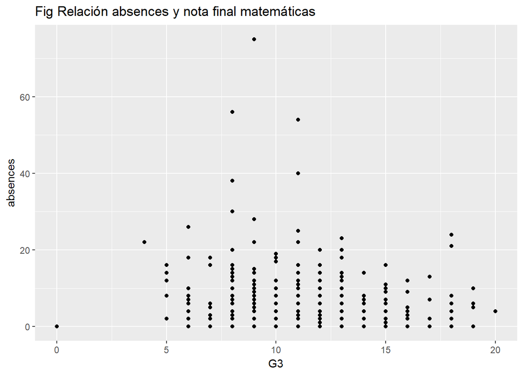

Primeramente se puede ver que no hay mucha relación entre la nota final (G3) y absences. Por esta misma razon, se decide mantener los outliers ya que parecen que no son errores de entrada. Lo deseable sería conocer cuantos días totales había clase y, a partir de aquí, ver si es factible el tener ese número de ausencias.

## 2.4. Análisis de los atributos frente al target

###### ^

La siguiente función permite comparar los atributos frente a la variable target G3 construyendo histogramas o geompoint para variables numéricas y diagrama de barras para los factores. Como se ha hecho anteriormente, las gráficas no son incluidas pero se han utilizado para sacar conclusiones, siendo las mismas para matemáticas y portugués a no ser que se diga lo contrario:

```r
# Functión que a partir de un dataframe y la columna target, crea histogramas or diagrama de puntos (geompointForNumeric false para el primero y true para el segundo) para atributos continous frente al target o diagrama de barras si el atributo es un factor.
DrawNumericplotFactorhistogramAgainstargetAllColumns <- function (dataframe, columnnametarget, datasettitle = "", geompointForNumeric = FALSE) {
  if (is.data.frame(dataframe)) {

    lapply(colnames(dataframe), function (colName) {
      if (colName != columnnametarget) {
        if (is.numeric(dataframe[, colName])) {
          if (geompointForNumeric) {
            ggplot(dataframe, aes_string(x = colName, y = columnnametarget)) +
              geom_point() +
              ggtitle(paste0("Fig Geom point ", colName, " con el target ", columnnametarget, " en ", datasettitle))
          } else {
            ggplot(dataframe, aes_string(x = colName)) +
              geom_histogram(bfill = "white", colour = "black") +
              facet_grid(as.formula(paste0(columnnametarget, " ~ ", colName))) +
              ggtitle(paste0("Fig Histogramas ", colName, " con el target ", columnnametarget, " en ", datasettitle)) +
              xlab(colName) +
              ylab(columnnametarget)
          }
        } else if (is.factor(dataframe[, colName])) {
          ggplot(dataframe, aes_string(x = columnnametarget)) +
            geom_bar() +
            facet_wrap(as.formula(paste0(" ~ ", colName))) +
            ggtitle(paste0("Fig Diagrama barras ", colName, " con el target ", columnnametarget, " en ", datasettitle)) +
            xlab(columnnametarget) +
            ylab(colName)
          # geom_bar(aes(y = (..count..)/sum(..count..))) +
          # ylab("Porcentaje")
        }
      }
    } )
  }
}
```

```r
DrawNumericplotFactorhistogramAgainstargetAllColumns(studentMat, "G3", datasettitle="matemáticas")
DrawNumericplotFactorhistogramAgainstargetAllColumns(studentPor, "G3", datasettitle="portugués")
```

- En matemáticas tanto **G1** como **G2** suelen ser mayores que la propia G3. En cambio en portugués pasa lo contrario.
- Al contrario de lo que se suponía, **absences** no afecta claramente a la nota final.
- Se puede pensar que cuanto peor es la salud **health** de un alumno, más necesitara ir a consulta perdiéndose clases, lo que podría afectar a la nota final. Pero los gráficos no muestran este razonamiento.
- **Dalc** es decir el consumo de alcohol diariamente sí que afecta a G3: cuanto mayor es el consumo, peor son las mejores notas.
- Ni **freetime** ni **goout** parecen tener relación con G3. Aunque en portugués, aquellos que no salen, sus mejores notas suelen ser peores.
- Una buena relación familiar **famrel** suele convertirse en una mejor nota en matemáticas pero no en portugués.
- Si el alumno dispone de **internet** su nota suele ser ligeramente superior, a diferencia de lo que se creia al principio (tendría gran influencia en la nota).
- Si el alumno no quiere cursar estudios superiores **higher** sus notas suelen ser bajas.
- Al contrario de lo que se pensaba, el ir a clases extra **paid** de la asignatura en cuestión, no asegura una mejor nota. Aquí cabe destacar el gran grupo de alumnos que no va a clases de matemáticas y su nota final es un 0.
- Cuantas más asignaturas se han suspendido **failures** menor son las notas.
- Interesante ver que el tiempo dedicado al estudio **studytime** no es decisivo para la nota final.
- El tiempo que puede ser decisivo a la hora de conseguir buenas notas es **traveltime**.
- Ni la educación de la madre **Fedu** ni del padre **Pedu**, ni si viven juntos o separados **Pstatus** parece afectar a la nota final.
- Si el alumnos es de sexo masculino **sex** suele tener peores notas en portugués.

El resto de atributos se han analizado pero no se ha sacado ninguna relación con el target.

## 2.5. Correlación atributos numéricos

###### ^

Por último se mostrará la correlación de los atributos numéricos. Para ello, lo primero es obtener una matriz con sólo los atributos de esta clase:

```r
# Función que dado un dataframe, retorna el tipo de columnas que se le pase por parametro: numericas y/o factores
GetOnlyNumericOrFactorColumns <- function (dataframe, columnsnumeric=TRUE, columnsfactor=FALSE) {
  dataframeFiltered <- dataframe

  if (is.data.frame(dataframe)) {

    lapply(colnames(dataframe), function (colName) {
      if (! columnsnumeric && ! columnsfactor) {
        dataframeFiltered[, colName] <<- NULL
      } else if (columnsnumeric && columnsfactor) {
        if(! is.numeric(dataframe[, colName]) && ! is.factor(dataframe[, colName])){
          dataframeFiltered[, colName] <<- NULL
        }
      } else if (columnsnumeric && ! columnsfactor) {
        if(! is.numeric(dataframe[, colName])){
          dataframeFiltered[, colName] <<- NULL
        }
      } else if (! columnsnumeric && columnsfactor) {
        if(! is.factor(dataframe[, colName])){
          dataframeFiltered[, colName] <<- NULL
        }
      } else {
        dataframeFiltered[, colName] <<- NULL
      }
    } )

    dataframeFiltered
  }
}

studentMatOnlyNumeric <- GetOnlyNumericOrFactorColumns(studentMat)
studentPorOnlyNumeric <- GetOnlyNumericOrFactorColumns(studentPor)
```

Una vez que se tiene los dataframes con sólo datos numéricos, se crea y se muestra la matriz de correlación:

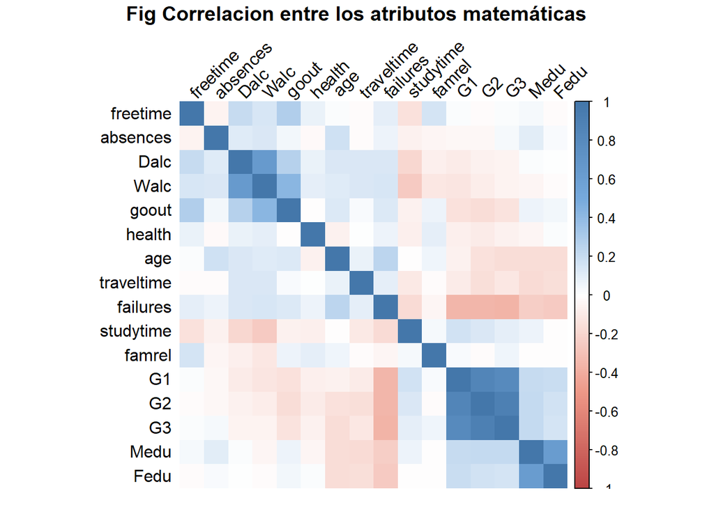

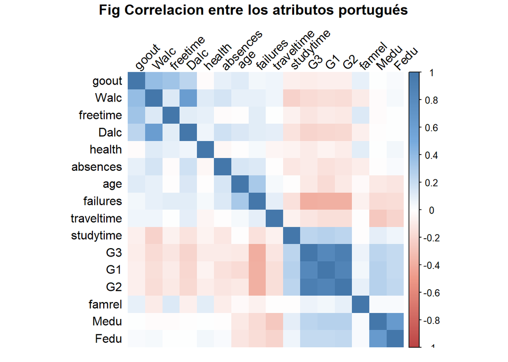

# 3. Análisis exploratorio con modelos NO supervisados

###### Ir a la introducción < >

3.1. K-means

Para hacer un análisis exploratorio de los datos se va utilizar un cluster k-means con datos numéricos. Después se asignará su cluster a todas las observaciones en el dataset con todos los atributos y se analizarán (incluidos los categóricos).

## 3.1. K-means

###### ^

3.1.1. Matemáticas 3.1.2. Portugués

Lo primero que se hace es aplicar el método de Elbow para saber el número de clusters óptimo.

Se ha elegido `5` para el conjunto de matemáticas y `4` para portugués. Con ello se construye el modelo y se añade el cluster id a cada observación:

```
## K-means clustering with 5 clusters of sizes 5, 127, 152, 39, 72
##
## Cluster means:
##        age     Medu     Fedu traveltime studytime   failures   famrel
## 1 17.80000 3.000000 3.000000   1.400000  2.000000 0.40000000 4.200000
## 2 16.40945 3.015748 2.748031   1.338583  2.141732 0.05511811 4.031496
## 3 16.58553 2.539474 2.394737   1.546053  2.039474 0.31578947 4.000000
## 4 17.02564 2.282051 2.256410   1.589744  1.974359 0.94871795 3.820513
## 5 17.18056 2.958333 2.500000   1.361111  1.875000 0.52777778 3.722222
##   freetime    goout     Dalc     Walc   health    absences        G1
## 1 2.200000 2.600000 1.400000 2.000000 3.600000 52.60000000 10.200000
## 2 3.307087 2.937008 1.354331 2.047244 3.496063  3.04724409 14.488189
## 3 3.184211 3.131579 1.486842 2.361842 3.611842  3.34868421  9.125000
## 4 3.128205 3.230769 1.358974 1.974359 3.641026  0.05128205  7.538462
## 5 3.347222 3.333333 1.763889 2.763889 3.486111 15.19444444 10.236111
##          G2         G3
## 1 10.000000  9.4000000
## 2 14.582677 14.8346457
## 3  9.480263  9.6118421
## 4  4.692308  0.1282051
## 5  9.805556  9.9583333
##
## Clustering vector:
##   [1] 3 3 5 2 3 2 3 3 2 2 3 3 2 3 2 2 2 3 5 3 2 2 2 2 3 5 3 2 3 5 3 2 2 3 2
##  [36] 3 2 2 3 2 5 3 2 3 5 3 5 2 2 3 2 2 3 3 3 3 2 2 3 2 3 3 3 3 3 2 2 3 3 2
##  [71] 2 3 4 2 1 3 3 3 3 5 3 3 5 2 3 3 3 2 5 5 3 2 3 3 2 3 2 3 2 3 5 2 2 5 2
## [106] 5 3 2 3 2 2 3 3 2 3 2 2 2 5 2 2 2 2 5 3 2 3 3 4 2 4 4 5 5 4 4 4 4 2 2
## [141] 4 3 3 2 4 3 4 3 4 3 4 2 3 4 3 3 2 3 2 3 4 3 4 3 3 5 3 2 4 2 4 2 3 4 3
## [176] 3 2 3 5 3 5 2 2 1 5 5 3 2 3 3 5 3 5 3 2 2 2 3 5 3 2 3 3 5 3 5 3 5 3 3
## [211] 5 5 2 5 5 2 5 5 3 3 3 4 2 2 2 5 2 3 5 5 5 3 5 2 5 5 2 5 3 4 5 3 4 2 4
## [246] 2 2 5 3 2 3 3 3 3 3 3 2 5 2 4 5 3 2 3 4 2 3 3 5 4 5 2 3 2 3 3 1 5 5 3
## [281] 5 5 3 3 3 3 2 2 2 2 5 2 5 2 2 2 4 5 2 2 5 3 2 2 5 2 2 1 2 5 4 5 3 5 5
## [316] 1 4 3 3 3 5 5 3 2 2 3 2 3 3 2 3 2 4 4 4 5 5 4 2 3 3 4 2 4 3 2 2 3 2 5
## [351] 3 2 3 3 3 3 2 3 3 2 2 2 3 2 3 3 2 4 3 5 3 2 3 5 2 3 2 3 2 5 2 3 3 4 5
## [386] 3 3 4 3 4 5 2 3 3 3
##
## Within cluster sum of squares by cluster:
## [1]  965.600 4059.890 4473.816 1170.821 4377.097
##  (between_SS / total_SS =  69.0 %)
##
## Available components:
##
## [1] "cluster"      "centers"      "totss"        "withinss"
## [5] "tot.withinss" "betweenss"    "size"         "iter"
## [9] "ifault"
```

```
## K-means clustering with 4 clusters of sizes 251, 102, 141, 155
##
## Cluster means:
##        age     Medu     Fedu traveltime studytime   failures   famrel
## 1 16.37849 2.561753 2.406375   1.490040  2.011952 0.03984064 3.980080
## 2 17.26471 2.401961 2.274510   1.568627  1.735294 0.40196078 3.764706
## 3 16.74468 3.000000 2.624113   1.411348  2.290780 0.01418440 4.021277
## 4 16.99355 2.070968 1.877419   1.838710  1.600000 0.58709677 3.877419
##   freetime    goout     Dalc     Walc   health  absences        G1
## 1 3.067729 3.000000 1.402390 2.115538 3.573705  1.860558 11.737052
## 2 3.127451 3.480392 2.009804 2.833333 3.539216 12.068627 10.166667
## 3 3.163121 3.099291 1.212766 1.900709 3.304965  2.375887 14.950355
## 4 3.412903 3.367742 1.593548 2.529032 3.683871  2.206452  8.432258
##         G2       G3
## 1 11.82072 12.28685
```

[output cut: 34 more lines]

Una vez obtenidos los clusters y etiquetadas las filas, se representan los valores de todos los atributos frente a cada cluster. De esta forma podríamos obtener alguna relación entre atributos categóricos (que se habían descartado para el cluster por ser de esta clase) y numéricos. Como se ha hecho anteriormente, estos gráficos no se han incluido en el documento pero se han utilizado.

#### 3.1.2. Portugués

###### ^

- Cluster 3:
  - Es el grupo con mayor nota **G3** y el único en los que todos es mayor que 10 en todas las notas incluidos **G1** y **G2**.
  - En todos los clusters excepto en el 4 las notas (G1, G2, G3) van aumentando.
  - Todos desean cursar estudios superiores **higher**.
  - Prácticamente ninguno suspende otras asignaturas.
  - La educación de los padres **Fedu** y **Medu** es la mayor de todos los grupos.
- Cluster 4:
  - Es el único grupo en el que el centroide es menor que 10 en **G1**, **G2** y **G3**.
  - Es el grupo donde los alumnos supenden más asignaturas **failures**.
- Cluster 1:
  - El valor del centroide en **G3** es la segunda mejor (12.2) estando los valores muy centrados, habiendo un único alumno por debajo del 10 (9).
  - Muchos desean un cursar estudios superiores **higher**
  - La gran mayoría vive con la familia junta **Pstatus**.
  - El es grupo más joven **age**.
- Cluster 2:
  - El valor del centroide **G3** está cerca del 11 pero la dispersión es muy grande siendo la nota más baja 5 y la más alta 17.
  - El número de ausencias **absences** es bastante elevado, siendo el único que tiene alumnos con 11 o más.

# 4. Selección de variables y construcción de dos modelos supervisados

###### Ir a la introducción < >

4.1. Selección de variable 4.2. Modelos supervisados

Para este apartado se utilizará el paquete **caret**.

## 4.1. Selección de variable

###### ^

Lo primero que se hace es dividir ambos dataset en dos grupos: training y test siendo la proporción 70/30. Para ello se utilizará createDataPartition y así asegurar que haya valores de target balanceados en ambos conjuntos.

A continuación se buscan atributos en el training cuya varianza este muy cerca de 0 y no aportan valor al modelo ya que serían considerados como una constante:

En ambos datasets no hay ningun atributo con varianza nula por lo que no se elimina ninguna columna.

El siguiente paso es eliminar aquellos atributos predictores que estén muy relacionados/correlados entre sí. Para ello:

1. Se filtran los dataset train para obtener únicamente los atributos numéricos
2. Con este nuevo subset, se obtiene la matriz de correlación entre los predictores
3. Con la ayuda de la función findCorrelation, se buscan las correlaciones cuyo valor sea mayor que 0.8 y se obtienen los índices de las columnas correladas de estos subsets
4. No se puede aplicar directamente este índice para eliminar las columnas en los datasets con todos los atributos ya que estas columnas podrian tener distinto indice (se recuerda que en el primer paso se filtraron sólo las variables continuas para crear la matriz de correlación). Por este motivo, se tiene que obtener el nombre de las columnas en los subsets.
5. Se itera sobre estos nombres de columnas y se eliminan de los dataset originales: training y test

Se obtienen:

- Matemáticas: `1` atributos correlados (`G2`) los cuales se eliminan.
- Portugués: `1` atributos correlados (`G2`) los cuales se eliminan.

Por último se centran y se escalan las variables predictoras para reducir la desviación con la función: se utiliza la función preProcess y se aplica a cada uno de los datasets (training y test).

## 4.2. Modelos supervisados

###### ^

4.2.1. Regresión Lineal Multivariable 4.2.2. Random Forest

En esta seccion se crearán dos modelos supervisados de predicción. Más concretamente se utilizará **Regresion Lineal Multivariable** y **Random Forest** a través del paquete caret. Además, se utilizará Cross Validation con 10 folds.

#### 4.2.1. Regresión Lineal Multivariable

###### ^

Se crea el modelo para los dos datasets de training (matemáticas y portugués):

A continuación se muestra el summary de los dos modelos creados:

```
##
## Call:
## lm(formula = .outcome ~ ., data = dat)
##
## Residuals:
##     Min      1Q  Median      3Q     Max
## -7.2853 -1.0387  0.2065  1.5192  5.4091
##
## Coefficients:
##                  Estimate Std. Error t value Pr(>|t|)
## (Intercept)       9.57718    1.42329   6.729 1.26e-10 ***
## schoolMS          0.91664    0.57819   1.585  0.11421
## sexM              0.28884    0.38217   0.756  0.45052
## age              -0.68025    0.20754  -3.278  0.00120 **
## addressU         -0.09181    0.42887  -0.214  0.83068
## famsizeLE3        0.40695    0.38670   1.052  0.29371
## PstatusT         -0.49747    0.54068  -0.920  0.35846
## Medu              0.39089    0.28115   1.390  0.16573
## Fedu             -0.03591    0.24470  -0.147  0.88345
## Mjobhealth       -0.42771    0.86435  -0.495  0.62117
## Mjobother         0.45520    0.52544   0.866  0.38719
## Mjobservices     -0.17779    0.61456  -0.289  0.77260
## Mjobteacher      -0.61663    0.78819  -0.782  0.43479
## Fjobhealth        0.61905    1.16186   0.533  0.59466
## Fjobother         0.75145    0.82248   0.914  0.36183
## Fjobservices      0.35681    0.83483   0.427  0.66947
## Fjobteacher      -0.29522    1.02991  -0.287  0.77463
## reasonhome       -0.15771    0.41001  -0.385  0.70085
## reasonother       0.87643    0.62366   1.405  0.16124
## reasonreputation -0.22320    0.45606  -0.489  0.62500
## guardianmother   -0.01195    0.40896  -0.029  0.97672
## guardianother     0.33980    0.76583   0.444  0.65766
## traveltime       -0.13462    0.17933  -0.751  0.45357
## studytime        -0.06885    0.18230  -0.378  0.70602
## failures          0.06067    0.19964   0.304  0.76147
## schoolsupyes      1.28475    0.51699   2.485  0.01364 *
## famsupyes         0.35878    0.36680   0.978  0.32901
## paidyes           0.42406    0.35469   1.196  0.23305
## activitiesyes    -0.16336    0.33898  -0.482  0.63031
## nurseryyes        0.16213    0.41629   0.389  0.69728
## higheryes         0.01485    0.80959   0.018  0.98538
## internetyes       0.06150    0.44965   0.137  0.89132
## romanticyes      -0.94412    0.35080  -2.691  0.00762 **
## famrel            0.23871    0.16877   1.414  0.15855
## freetime         -0.10198    0.18312  -0.557  0.57813
## goout            -0.18961    0.18576  -1.021  0.30842
## Dalc             -0.25484    0.22994  -1.108  0.26887
## Walc              0.46454    0.24576   1.890  0.05995 .
## health            0.25428    0.17440   1.458  0.14615
## absences          0.32579    0.17482   1.864  0.06361 .
## G1                4.01430    0.19777  20.298  < 2e-16 ***
## ---
## Signif. codes:  0 '***' 0.001 '**' 0.01 '*' 0.05 '.' 0.1 ' ' 1
##
## Residual standard error: 2.579 on 238 degrees of freedom
## Multiple R-squared:  0.7458, Adjusted R-squared:  0.703
## F-statistic: 17.45 on 40 and 238 DF,  p-value: < 2.2e-16
```

```
##
## Call:
## lm(formula = .outcome ~ ., data = dat)
##
## Residuals:
##     Min      1Q  Median      3Q     Max
## -8.3792 -0.6621  0.1009  0.9590  7.7462
##
## Coefficients:
##                   Estimate Std. Error t value Pr(>|t|)
## (Intercept)      12.642463   0.642382  19.681  < 2e-16 ***
## schoolMS         -0.319410   0.207109  -1.542 0.123779
## sexM             -0.278580   0.196989  -1.414 0.158056
## age               0.271956   0.095326   2.853 0.004549 **
## addressU          0.153016   0.202192   0.757 0.449609
## famsizeLE3        0.141178   0.192011   0.735 0.462598
## PstatusT         -0.174290   0.271492  -0.642 0.521247
## Medu             -0.049059   0.128745  -0.381 0.703360
## Fedu              0.111464   0.114023   0.978 0.328865
## Mjobhealth        0.362242   0.404005   0.897 0.370438
## Mjobother        -0.251540   0.235475  -1.068 0.286042
## Mjobservices      0.012872   0.283636   0.045 0.963825
## Mjobteacher       0.209363   0.411803   0.508 0.611439
## Fjobhealth       -0.269995   0.600992  -0.449 0.653486
## Fjobother        -0.197590   0.342250  -0.577 0.564031
## Fjobservices     -0.618912   0.359036  -1.724 0.085486 .
## Fjobteacher      -0.152362   0.543884  -0.280 0.779512
## reasonhome       -0.346508   0.222563  -1.557 0.120257
## reasonother      -0.531983   0.288636  -1.843 0.066028 .
## reasonreputation -0.168500   0.227443  -0.741 0.459207
## guardianmother    0.063309   0.205144   0.309 0.757775
## guardianother    -0.108597   0.441521  -0.246 0.805834
## traveltime        0.081286   0.092582   0.878 0.380458
## studytime        -0.002321   0.090304  -0.026 0.979504
## failures         -0.363327   0.096871  -3.751 0.000201 ***
## schoolsupyes      0.020006   0.281843   0.071 0.943446
## famsupyes         0.061554   0.178843   0.344 0.730884
## paidyes           0.215583   0.356689   0.604 0.545908
## activitiesyes    -0.121447   0.178540  -0.680 0.496741
## nurseryyes       -0.264786   0.217443  -1.218 0.224018
## higheryes        -0.031696   0.308114  -0.103 0.918114
## internetyes       0.337607   0.209489   1.612 0.107814
## romanticyes      -0.050687   0.183763  -0.276 0.782818
## famrel            0.092079   0.088553   1.040 0.299030
## freetime         -0.104066   0.090906  -1.145 0.252966
## goout            -0.047024   0.096636  -0.487 0.626792
## Dalc             -0.120306   0.112555  -1.069 0.285752
## Walc             -0.059651   0.119702  -0.498 0.618517
## health           -0.139167   0.087006  -1.600 0.110467
## absences          0.082119   0.090035   0.912 0.362256
## G1                2.451670   0.104667  23.423  < 2e-16 ***
## ---
## Signif. codes:  0 '***' 0.001 '**' 0.01 '*' 0.05 '.' 0.1 ' ' 1
##
## Residual standard error: 1.721 on 415 degrees of freedom
## Multiple R-squared:  0.7392, Adjusted R-squared:  0.7141
## F-statistic: 29.41 on 40 and 415 DF,  p-value: < 2.2e-16
```

El siguiente paso es predecir el valor target en el conjunto de test. Empezaremos con matemáticas:

```
##      RMSE  Rsquared       MAE
## 2.9594756 0.5477779 2.2465327
```

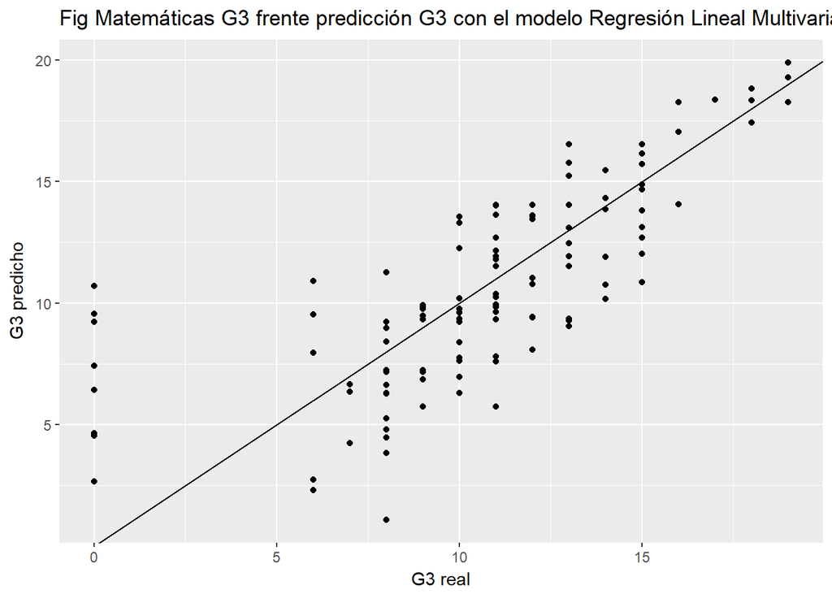

El RMSE en el conjunto de test es `2.9594756` y el R<sup>2</sup> es `0.5477779`. Se puede ver que RMSE no es muy bueno. El modelo ideal sería aquel donde todos los puntos (G3 frente G3 predicho) estuviesen en la linea (G3 es igual a G3 predicho); visualmente se ve que esto no es así y se comete bastante error.

A continuación hacemos el mismo proceso para el portugués, aunque no se muestre el plot:

```
##      RMSE  Rsquared       MAE
## 1.9672983 0.6373126 1.3469952
```

En este caso RMSE es `1.9672983` y el R<sup>2</sup> es `0.6373126`, por lo que este modelo, de nuevo, se adapta mejor a la asignatura de portugués que de matemáticas.

#### 4.2.2. Random Forest

###### ^

Se crea el modelo para los dos datasets de training (matemáticas y portugués):

A continuación se muestra el summary de los dos modelos creados:

```
## Random Forest
##
## 279 samples
##  31 predictor
##
## No pre-processing
## Resampling: Cross-Validated (10 fold)
## Summary of sample sizes: 251, 251, 250, 251, 250, 252, ...
## Resampling results:
##
##   RMSE      Rsquared   MAE
##   4.097231  0.5092976  3.039849
##
## Tuning parameter 'mtry' was held constant at a value of 1
```

```
## Random Forest
##
## 456 samples
##  31 predictor
##
## No pre-processing
## Resampling: Cross-Validated (10 fold)
## Summary of sample sizes: 411, 410, 411, 410, 411, 410, ...
## Resampling results:
##
##   RMSE      Rsquared   MAE
##   2.661398  0.5358816  1.917812
##
## Tuning parameter 'mtry' was held constant at a value of 1
```

- Matemáticas:
  - RMSE es `4.0972312` y R<sup>2</sup> es `0.5092976`
- Portugués:
  - RMSE es `2.6613977` y R<sup>2</sup> es `0.5358816`
  - En este caso también se obtiene menor error de predicción en el conjunto de training que en matemáticas. Puede influir que se tengan más observaciones en portugués que en matemáticas.

Ahora vamos a ver como de bien predicen con los conjuntos de test. Empezamos con matemáticas:

```
##      RMSE  Rsquared       MAE
## 3.7780295 0.3391764 2.7940219
```

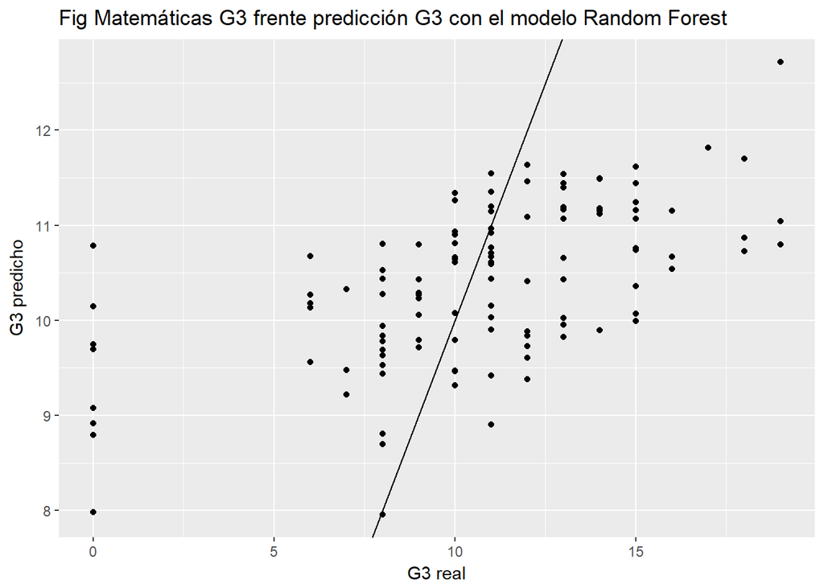

Ahora predecimos las notas de portugués:

```
##      RMSE  Rsquared       MAE
## 2.8189598 0.4212733 1.9728171
```

Si se representa gráficamente (descomentar ggplot) se puede observar que la predicción no es tampoco buena, aunque no es tan mala como con matemáticas. Lo más llamativo es que muchas notas con valor 0 en el G3 real, el G3 predicho es mayor que 10. De nuevo, numéricamente se represanta como RMSE `2.8189598` y R<sup>2</sup> `0.4212733`.

# 5. Evaluación y comparación de modelos supervisados

###### Ir a la introducción <

Primeramente se comparan los modelos generados para el dataset de matemáticas. Para ello se utiliza la funcion resamples:

```
##
## Call:
## summary.resamples(object = comparRegModelsMat)
##
## Models: Model1, Model2
## Number of resamples: 10
##
## MAE
##            Min.  1st Qu.   Median     Mean 3rd Qu.     Max. NA's
## Model1 1.382102 2.036083 2.153290 2.188626 2.46383 2.800612    0
## Model2 2.238491 2.994470 3.057364 3.039849 3.28223 3.616755    0
##
## RMSE
##            Min.  1st Qu.   Median     Mean  3rd Qu.     Max. NA's
## Model1 2.305743 2.562229 2.706726 2.819164 2.989470 3.533983    0
## Model2 2.910183 4.018009 4.232334 4.097231 4.390848 4.863099    0
##
## Rsquared
##             Min.   1st Qu.    Median      Mean   3rd Qu.      Max. NA's
## Model1 0.5732942 0.6010003 0.6746055 0.6677645 0.7017838 0.8047735    0
## Model2 0.2757716 0.4688011 0.5168861 0.5092976 0.5531301 0.6936575    0
```

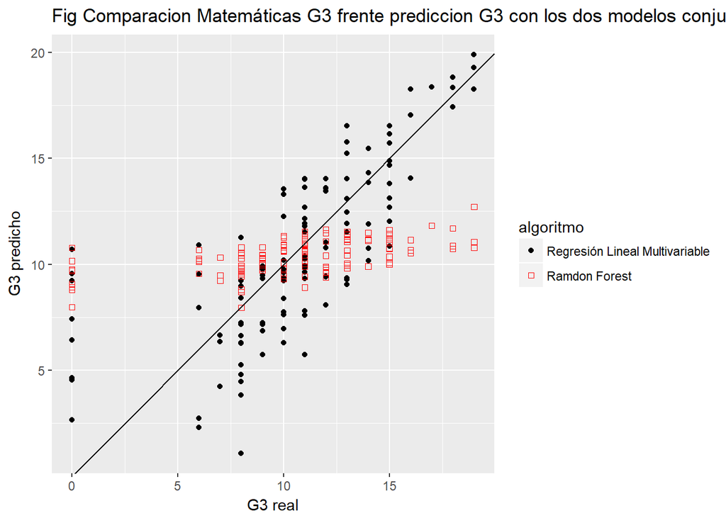

En el gráfico se puede observar perfectamente la diferencia de predicción de los modelos donde los círculos negros son los valores G3~G3 predicho con Regresión Lineal Multivariable y los cuadrados rojos con Ramdon Forest. Los datos utilizados son los del test:

- Utilizando caret: RMSE media para Regresión Lineal Multivariable es `2.819164` y R<sup>2</sup> medio de `0.6677645`
- Utilizando caret: RMSE media para Ramdon Forest es `4.0972312` y R<sup>2</sup> medio de `0.5092976`
- Utilizando conjunto de test: RMSE media para Regresión Lineal Multivariable es `2.9594756` y R<sup>2</sup> medio de `0.5477779`
- Utilizando conjunto de test: RMSE media para Ramdon Forest es `3.7780295` y R<sup>2</sup> medio de `0.3391764`

Vamos a ver ahora con el dataset de portugués:

```
##
## Call:
## summary.resamples(object = comparRegModelsPor)
##
## Models: Model1, Model2
## Number of resamples: 10
##
## MAE
##             Min.  1st Qu.   Median     Mean  3rd Qu.     Max. NA's
## Model1 0.8130038 1.075839 1.203269 1.214931 1.288393 1.763051    0
## Model2 1.5059394 1.820224 1.853592 1.917812 2.048612 2.319050    0
##
## RMSE
##            Min.  1st Qu.   Median     Mean  3rd Qu.     Max. NA's
## Model1 1.066316 1.534044 1.777881 1.774243 2.014136 2.706507    0
## Model2 1.862756 2.364800 2.619398 2.661398 2.856556 3.642746    0
##
## Rsquared
##             Min.   1st Qu.    Median      Mean   3rd Qu.      Max. NA's
## Model1 0.5351898 0.6337252 0.6941166 0.6980265 0.7818223 0.8549698    0
## Model2 0.3236160 0.4726232 0.5146797 0.5358816 0.6301798 0.6852251    0
```

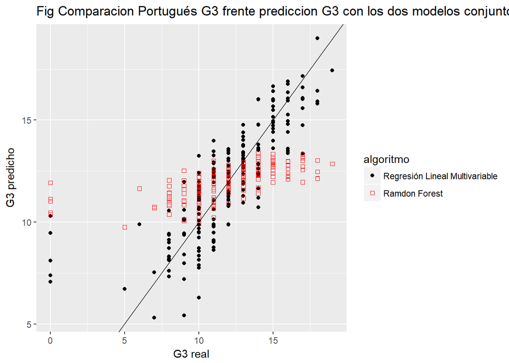

Al igual que con matemáticas, se observa gráficamente que el que mejor predice es Regresión Lineal Multivariable (círculos negros) con bastante distancia respecto a Ramdon Forest (cuadrados rojos) con los datos de test. No obstante este Ramdon Forest predice mejor que en matemáticas donde se puede catalogar como penoso:

Como se vio en teoría, los árboles no predicen tan bien como la regresión lineal.

[^1]: https://archive.ics.uci.edu/ml/machine-learning-databases/00320/student.zip
[^2]: https://archive.ics.uci.edu/ml/datasets/Student+Performance